# 1.transform (exercises)

## 2.3. MODIFYING FACTOR ORDER

a) For each factor in gss_cat identify whether the order of the levels is arbitrary or principled.

```r
gss_cat |> count(marital) #somewhat principled
```

```
## # A tibble: 6 × 2
##   marital           n
##   <fct>         <int>
## 1 No answer        17
## 2 Never married  5416
## 3 Separated       743
## 4 Divorced       3383
## 5 Widowed        1807
## 6 Married       10117
```

```r
gss_cat |> count(race)    #principled by count of observations
```

```
## # A tibble: 3 × 2
##   race      n
##   <fct> <int>
## 1 Other  1959
## 2 Black  3129
## 3 White 16395
```

```r
gss_cat |> count(rincome) #principled
```

```
## # A tibble: 16 × 2
##    rincome            n
##    <fct>          <int>
##  1 No answer        183
##  2 Don't know       267
##  3 Refused          975
##  4 $25000 or more  7363
##  5 $20000 - 24999  1283
##  6 $15000 - 19999  1048
##  7 $10000 - 14999  1168
##  8 $8000 to 9999    340
##  9 $7000 to 7999    188
## 10 $6000 to 6999    215
## 11 $5000 to 5999    227
## 12 $4000 to 4999    226
## 13 $3000 to 3999    276
## 14 $1000 to 2999    395
## 15 Lt $1000         286
## 16 Not applicable  7043
```

```r
gss_cat |> count(partyid) #principled
```

```
## # A tibble: 10 × 2
##    partyid                n
##    <fct>              <int>
##  1 No answer            154
##  2 Don't know             1
##  3 Other party          393
##  4 Strong republican   2314
##  5 Not str republican  3032
##  6 Ind,near rep        1791
##  7 Independent         4119
##  8 Ind,near dem        2499
##  9 Not str democrat    3690
## 10 Strong democrat     3490
```

```r
gss_cat |> count(relig)   #arbitrary
```

```
## # A tibble: 15 × 2
##    relig                       n
##    <fct>                   <int>
##  1 No answer                  93
##  2 Don't know                 15
##  3 Inter-nondenominational   109
##  4 Native american            23
##  5 Christian                 689
##  6 Orthodox-christian         95
##  7 Moslem/islam              104
##  8 Other eastern              32
##  9 Hinduism                   71
## 10 Buddhism                  147
## 11 Other                     224
## 12 None                     3523
## 13 Jewish                    388
## 14 Catholic                 5124
## 15 Protestant              10846
```

```r
gss_cat |> count(denom)   #arbitrary
```

```
## # A tibble: 30 × 2
##    denom                    n
##    <fct>                <int>
##  1 No answer              117
##  2 Don't know              52
##  3 No denomination       1683
##  4 Other                 2534
##  5 Episcopal              397
##  6 Presbyterian-dk wh     244
##  7 Presbyterian, merged    67
##  8 Other presbyterian      47
##  9 United pres ch in us   110
## 10 Presbyterian c in us   104
## # ℹ 20 more rows
```

b) Why did moving “Not applicable” to the front of the levels move it to the bottom of the plot?

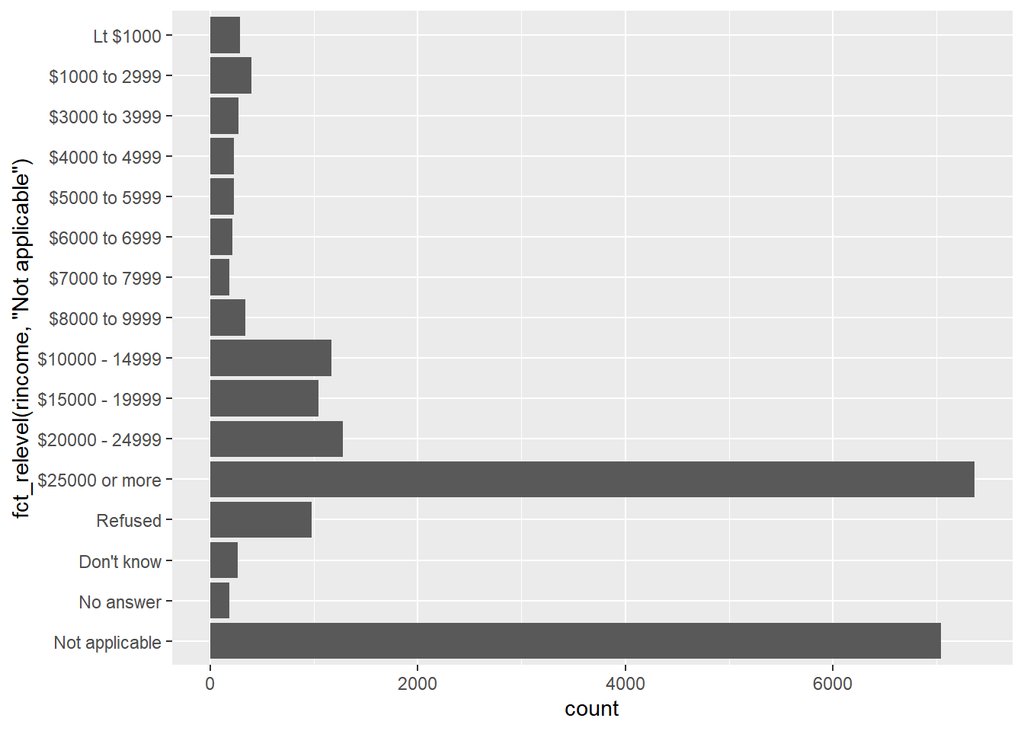

```r
gss_cat |>
  #move closer to origin of axis
  ggplot(aes(y = fct_relevel(rincome, "Not applicable"))) +
  geom_bar()
```

## 2.4. MODIFYING FACTOR LEVELS

a) How have the proportions of people identifying as Democrat, Republican, and Independent changed over time?

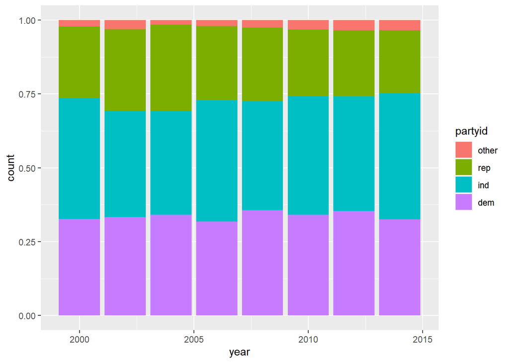

```r
gss_cat_mod <- gss_cat |>
  mutate(
    partyid = fct_collapse(partyid,
      "other" = c("No answer", "Don't know", "Other party"),
      "rep" = c("Strong republican", "Not str republican"),
      "ind" = c("Ind,near rep", "Independent", "Ind,near dem"),
      "dem" = c("Not str democrat", "Strong democrat")
    )
  )

gss_cat_mod |>
  ggplot(aes(x = year, fill = partyid)) +
  geom_bar(position = "fill")
```

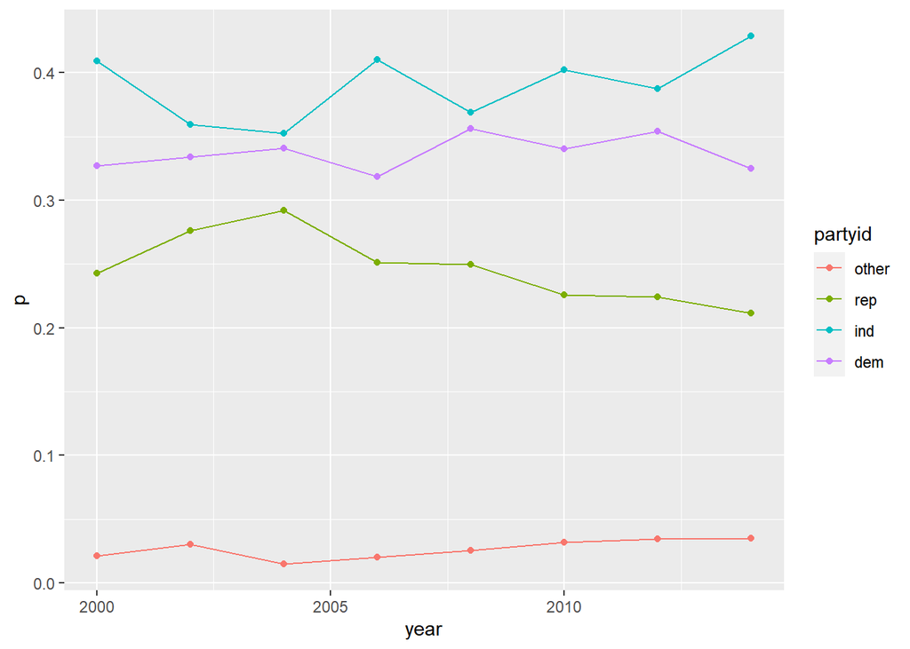

```r
gss_cat_mod |>
  count(year, partyid) |>
  group_by(year) |>
  mutate(p = n/sum(n)) |>
  ggplot(aes(x = year, y = p, colour = partyid)) +
  geom_point() +
  geom_line()
```

```r
rm(gss_cat_mod)
```

b) How could you collapse rincome into a small set of categories?

```r
gss_cat |> count(rincome)
```

```
## # A tibble: 16 × 2
##    rincome            n
##    <fct>          <int>
##  1 No answer        183
##  2 Don't know       267
##  3 Refused          975
##  4 $25000 or more  7363
##  5 $20000 - 24999  1283
##  6 $15000 - 19999  1048
##  7 $10000 - 14999  1168
##  8 $8000 to 9999    340
##  9 $7000 to 7999    188
## 10 $6000 to 6999    215
## 11 $5000 to 5999    227
## 12 $4000 to 4999    226
## 13 $3000 to 3999    276
## 14 $1000 to 2999    395
## 15 Lt $1000         286
## 16 Not applicable  7043
```

```r
gss_cat |>
  mutate(
    rincome = fct_collapse(rincome,
      "Not applicable" = "Not applicable",
      "N/A"            = c("No answer",
                           "Don't know",
                           "Refused"),
      "$25000 or more" = "$25000 or more",
      "$10000 - 24999" = c("$20000 - 24999",
                           "$15000 - 19999",
                           "$10000 - 14999"),
      "$5000 - 9999"   = c("$8000 to 9999",
                           "$7000 to 7999",
                           "$6000 to 6999",
                           "$5000 to 5999"),
      "Lt $5000"       = c("$4000 to 4999",
                           "$3000 to 3999",
                           "$1000 to 2999",
                           "Lt $1000")
    )
  ) |>
  count(rincome)
```

```
## # A tibble: 6 × 2
##   rincome            n
##   <fct>          <int>
## 1 N/A             1425
## 2 $25000 or more  7363
## 3 $10000 - 24999  3499
## 4 $5000 - 9999     970
## 5 Lt $5000        1183
## 6 Not applicable  7043
```

c) Notice there are 9 groups (excluding other) in the fct_lump example above. Why not 10? (Hint: type ?fct_lump, and find the default for the argument other_level is “Other”.)

```r
?fct_lump
```

```r
gss_cat |>
  mutate(relig = fct_lump_n(relig, n = 10)) |>
  count(relig) |>
  print(n = Inf)
```

```
## # A tibble: 10 × 2
##    relig                       n
##    <fct>                   <int>
##  1 Inter-nondenominational   109
##  2 Christian                 689
##  3 Orthodox-christian         95
##  4 Moslem/islam              104
##  5 Buddhism                  147
##  6 None                     3523
##  7 Jewish                    388
##  8 Catholic                 5124
##  9 Protestant              10846
## 10 Other                     458
```

```r
gss_cat |>
  mutate(relig = fct_lump_n(relig, n = 10, other_level="Other answer")) |>
  count(relig) |>
  print(n = Inf)
```

```
## # A tibble: 11 × 2
##    relig                       n
##    <fct>                   <int>
##  1 Inter-nondenominational   109
##  2 Christian                 689
##  3 Orthodox-christian         95
##  4 Moslem/islam              104
##  5 Buddhism                  147
##  6 Other                     224
##  7 None                     3523
##  8 Jewish                    388
##  9 Catholic                 5124
## 10 Protestant              10846
## 11 Other answer              234
```

# 3. LOGICAL VECTORS

[from https://r4ds.hadley.nz/logicals.html]

[see https://jrnold.github.io/r4ds-exercise-solutions/vectors.html]

[see https://mine-cetinkaya-rundel.github.io/r4ds-solutions/logicals.html]

```r
library("nycflights13")
library("tidyverse")
```

## 3.1. COMPARISONS

1. How does dplyr::near() work? Type near to see the source code. Is sqrt(2)^2 near 2?

```r
?near
near
```

```r
near(sqrt(2)^2, 2)
```

```
## [1] TRUE
```

```r
near(sqrt(2)^2, 2, tol = 1e-16)
```

```
## [1] FALSE
```

2. Use mutate(), is.na(), and count() together to describe how the missing values in dep_time, sched_dep_time and dep_delay are connected.?

```r
flights |>
  mutate(
    #calculate number of missing values for dep_time
    dt_na = is.na(dep_time),
    #calculate number of missing values for sched_dep_time
    sdt_na = is.na(sched_dep_time),
    #calculate number of missing values for dep_delay
    dd_na = is.na(dep_delay),
    .keep="used"
  ) |>
  #group by "dt_na", "sdt_na" and "dd_na"
  group_by(dt_na, sdt_na, dd_na) |>
  count()
```

```
## # A tibble: 2 × 4
## # Groups:   dt_na, sdt_na, dd_na [2]
##   dt_na sdt_na dd_na      n
##   <lgl> <lgl>  <lgl>  <int>
## 1 FALSE FALSE  FALSE 328521
## 2 TRUE  FALSE  TRUE    8255
```

## 3.2. BOOLEAN ALGEBRA

a) Find all flights where arr_delay is missing but dep_delay is not. Find all flights where neither arr_time nor sched_arr_time are missing, but arr_delay is.

```r
flights |>
  filter(is.na(arr_delay) & !is.na(dep_delay))
```

```
## # A tibble: 1,175 × 19
##     year month   day dep_time sched_dep_time dep_delay arr_time sched_arr_time
##    <int> <int> <int>    <int>          <int>     <dbl>    <int>          <int>
##  1  2013     1     1     1525           1530        -5     1934           1805
##  2  2013     1     1     1528           1459        29     2002           1647
##  3  2013     1     1     1740           1745        -5     2158           2020
##  4  2013     1     1     1807           1738        29     2251           2103
##  5  2013     1     1     1939           1840        59       29           2151
##  6  2013     1     1     1952           1930        22     2358           2207
##  7  2013     1     1     2016           1930        46       NA           2220
##  8  2013     1     2      905            822        43     1313           1045
##  9  2013     1     2     1125            925       120     1445           1146
## 10  2013     1     2     1848           1840         8     2333           2151
## # ℹ 1,165 more rows
## # ℹ 11 more variables: arr_delay <dbl>, carrier <chr>, flight <int>,
## #   tailnum <chr>, origin <chr>, dest <chr>, air_time <dbl>, distance <dbl>,
## #   hour <dbl>, minute <dbl>, time_hour <dttm>
```

```r
flights |>
  filter(!is.na(arr_time) & !is.na(sched_arr_time) & is.na(arr_delay))
```

```
## # A tibble: 717 × 19
##     year month   day dep_time sched_dep_time dep_delay arr_time sched_arr_time
##    <int> <int> <int>    <int>          <int>     <dbl>    <int>          <int>
##  1  2013     1     1     1525           1530        -5     1934           1805
##  2  2013     1     1     1528           1459        29     2002           1647
##  3  2013     1     1     1740           1745        -5     2158           2020
##  4  2013     1     1     1807           1738        29     2251           2103
##  5  2013     1     1     1939           1840        59       29           2151
##  6  2013     1     1     1952           1930        22     2358           2207
##  7  2013     1     2      905            822        43     1313           1045
##  8  2013     1     2     1125            925       120     1445           1146
##  9  2013     1     2     1848           1840         8     2333           2151
## 10  2013     1     2     1849           1724        85     2235           1938
## # ℹ 707 more rows
## # ℹ 11 more variables: arr_delay <dbl>, carrier <chr>, flight <int>,
## #   tailnum <chr>, origin <chr>, dest <chr>, air_time <dbl>, distance <dbl>,
## #   hour <dbl>, minute <dbl>, time_hour <dttm>
```

b) How many flights have a missing dep_time? What other variables are missing in these rows? What might these rows represent?

```r
flights |> filter(is.na(dep_time)) |> count()
```

```
## # A tibble: 1 × 1
##       n
##   <int>
## 1  8255
```

```r
flights |>
  #filter in cancelled flights
  filter(is.na(dep_time)) |>
  #select any columns with missing values
  select(where(~ any(is.na(.)))) |>
  #calculate number of missing values
  summarise(across(everything(),~ sum(is.na(.))))
```

```
## # A tibble: 1 × 6
##   dep_time dep_delay arr_time arr_delay tailnum air_time
##      <int>     <int>    <int>     <int>   <int>    <int>
## 1     8255      8255     8255      8255    2512     8255
```

c) Assuming that a missing dep_time implies that a flight is cancelled, look at the number of cancelled flights per day. Is there a pattern? Is there a connection between the proportion of cancelled flights and the average delay of non-cancelled flights?

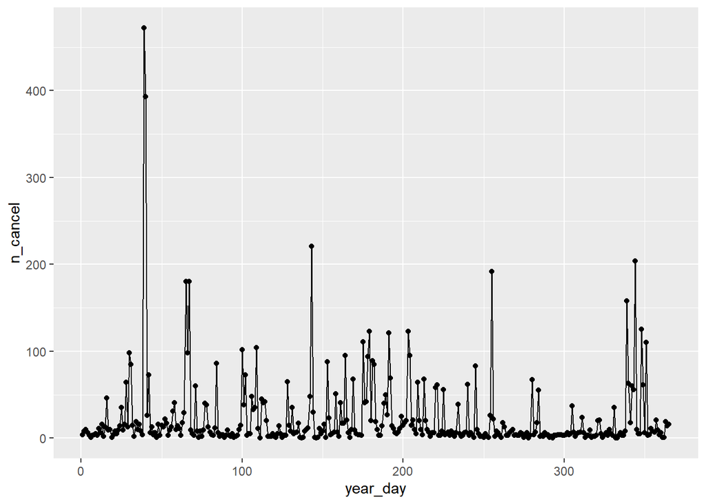

```r
flights |>
  #group by "year", "month", "day"
  group_by(year, month, day) |>
  summarise(
    #number of missing in "dep_time" per groups
    n_cancel = sum(is.na(dep_time)),
    .groups = "drop"
  ) |>
  mutate(
    #calculate day of the year
    year_day = row_number()
  ) |>
  ggplot(aes(x = year_day, y = n_cancel)) +
  geom_line() +
  geom_point()
```

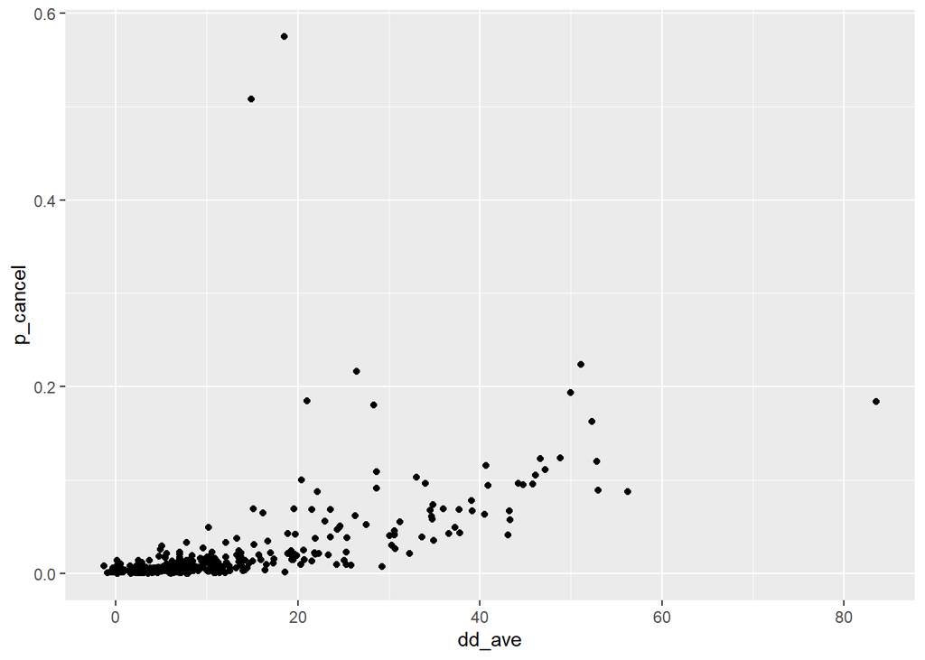

```r
flights |>
  #group by "year", "month", "day"
  group_by(year, month, day) |>
  summarise(
    #proportion of missing in "dep_time" per groups
    p_cancel = mean(is.na(dep_time)),
    #average departure delay per groups
    dd_ave   = mean(dep_delay, na.rm = TRUE),
    .groups = "drop"
  ) |>
  ggplot(aes(x = dd_ave, y = p_cancel)) +
  geom_point()
```

## 3.3. SUMMARIES

a) What will sum(is.na(x)) tell you? How about mean(is.na(x))?

```r
set.seed(123)
v_length <- 9
v <- 1:v_length
NA_index <- sample(1:v_length, size = (1/3)*v_length, replace = FALSE)
v[NA_index] <- NA
#v <- (1, 2, NA, 4, 5, NA, 7, 8, NA)
sum(is.na(v))
```

```
## [1] 3
```

```r
mean(is.na(v))
```

```
## [1] 0.3333333
```

b) What does prod() return when applied to a logical vector? What logical summary function is it equivalent to? What does min() return when applied to a logical vector? What logical summary function is it equivalent to? Read the documentation and perform a few experiments.

```r
?prod
?min
```

```r
v1 <- c(TRUE,  TRUE,  TRUE)
v2 <- c(FALSE, FALSE, FALSE)
v3 <- c(TRUE,  FALSE, FALSE)
prod(v1) #all(v1)
```

```
## [1] 1
```

```r
prod(v2) #all(v2)
```

```
## [1] 0
```

```r
prod(v3) #all(v3)
```

```
## [1] 0
```

```r
min(v1)  #any(v1)
```

```
## [1] 1
```

```r
min(v2)  #any(v2)
```

```
## [1] 0
```

```r
min(v3)  #any(v3)
```

```
## [1] 0
```

## 3.4. CONDITIONAL TRANSFORMATIONS

a) A number is even if it’s divisible by two, which in R you can find out with x %% 2 == 0. Use this fact and if_else() to determine whether each number between 0 and 20 is even or odd.

```r
tibble(numbers = 1:20) |>
  mutate(eve_odd = if_else(1:20 %% 2 == 0,"even","odd"))
```

```
## # A tibble: 20 × 2
##    numbers eve_odd
##      <int> <chr>
##  1       1 odd
##  2       2 even
##  3       3 odd
##  4       4 even
##  5       5 odd
##  6       6 even
##  7       7 odd
##  8       8 even
##  9       9 odd
## 10      10 even
## 11      11 odd
## 12      12 even
## 13      13 odd
## 14      14 even
## 15      15 odd
## 16      16 even
## 17      17 odd
## 18      18 even
## 19      19 odd
## 20      20 even
```

b) Given a vector of days like x <- c(“Monday”, “Saturday”, “Wednesday”), use an ifelse() statement to label them as weekends or weekdays.

```r
set.seed(123)
wdays <- c("Monday","Tuesday","Wednesday","Thursday","Friday","Saturday",
  "Sunday")
tibble(wday = sample(wdays,15,rep=TRUE)) |>
  mutate(wlab = if_else(wday %in% c("Saturday","Sunday"),"weekends","weekdays"))
```

```
## # A tibble: 15 × 2
##    wday      wlab
##    <chr>     <chr>
##  1 Sunday    weekends
##  2 Sunday    weekends
##  3 Wednesday weekdays
##  4 Saturday  weekends
##  5 Wednesday weekdays
##  6 Tuesday   weekdays
##  7 Tuesday   weekdays
##  8 Saturday  weekends
##  9 Wednesday weekdays
## 10 Friday    weekdays
## 11 Thursday  weekdays
## 12 Saturday  weekends
## 13 Saturday  weekends
## 14 Monday    weekdays
## 15 Tuesday   weekdays
```

c) Use ifelse() to compute the absolute value of a numeric vector called x.

```r
v <- -6:6
ifelse(v < 0, -v, v)
```

```
##  [1] 6 5 4 3 2 1 0 1 2 3 4 5 6
```

d) Write a case_when() statement that uses the month and day columns from flights to label a selection of important US holidays (e.g., New Years Day, 4th of July, Thanksgiving, and Christmas). First create a logical column that is either TRUE or FALSE, and then create a character column that either gives the name of the holiday or is NA.

```r
flights |>
  mutate(
    is_important =
      month ==  1 & day ==  1 |        #New Years Day
      month ==  4 & day ==  7 |        #4th of July
      month == 11 & day == 28 |        #Thanksgiving 2013
      month == 12 & day == 25,         #Christmas
    important_day = case_when(
      month ==  1 & day ==  1 ~ "New Years Day",
      month ==  4 & day ==  7 ~ "4th of July",
      month == 11 & day == 28 ~ "Thanksgiving",
      month == 12 & day == 25 ~ "Christmas"
    ),
    .keep = "used"
  ) |>
  group_by(is_important,important_day) |>
  count()
```

```
## # A tibble: 5 × 3
## # Groups:   is_important, important_day [5]
##   is_important important_day      n
##   <lgl>        <chr>          <int>
## 1 FALSE        <NA>          333670
## 2 TRUE         4th of July      911
## 3 TRUE         Christmas        719
## 4 TRUE         New Years Day    842
## 5 TRUE         Thanksgiving     634
```